# Using containers with Docker

# Run Docker containers interactively in the terminal

## Run R interactively in container

Oftentimes Docker is used to run a specific set of software interactively within the terminal. This allows for running custom scripts contained within the Docker container as well.

So far we have only been using the R Studio Docker image which provides it’s own user interface. Here we will use Docker to run a specific version of R and R packages in the terminal interactively. The Rocker suite has images that just contain R, without R studio.

## Run R interactively in container

All we have to do is change the base Docker image that we pull, and change the command at the end of the Dockerfile to ‘R’ so it will run R once we launch a container.

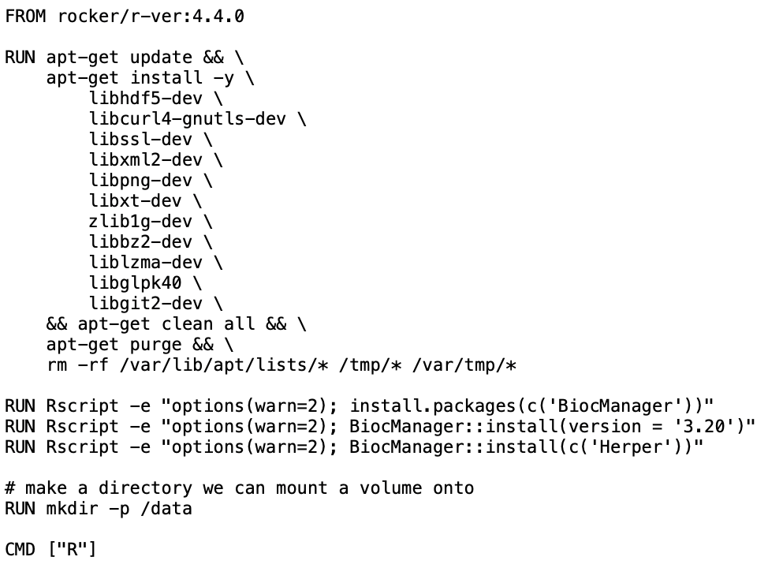

## Run R interactively in container

After building this image as we have done previously, it should be run with the ‘-it’ flag, which will run this container within an interactive terminal. Using these flags, when the ‘R’ command at the end of the Dockerfile is run upon launch, it will open the version of R in the image.

First we build this image from the Dockerfile like we’ve done before.

*Code (terminal):*

```bash
docker image build -t rocker/r-ver:4.4.0_cust -f ./data/Dockerfile_R ./data/
```

Then we run a container with the *data* directory mounted and the ‘-it’ flag.

*Code (terminal):*

```bash
cd ~/Downloads/RU_reproducibleR-master/r_course
docker container run -it -v ./data:/data  rocker/r-ver:4.4.0_cust
```

*output on next slide

## Run R interactively in container

*Output (terminal):*

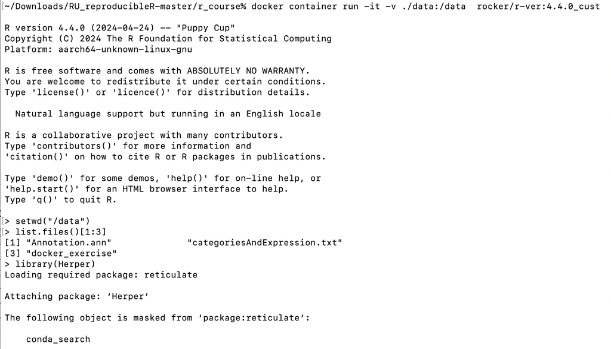

## Run Python interactively in container

Python also has [images available](https://hub.docker.com/_/python) on Docker Hub and we can make a Dockerfile that has a specific version of Python and any other packages we want available in that environment.

Here we pull the python image, use pip to install a Python package (scanpy), then end with the ‘python’ command to open a Python session in the terminal.

Dockerfile:

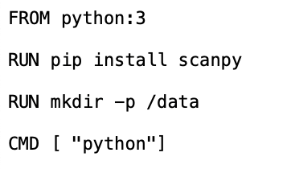

## Run Python interactively in container

*Code (terminal):*

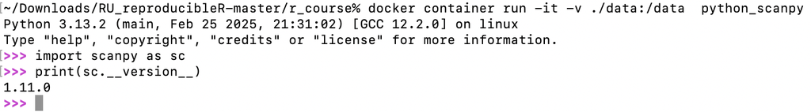

```bash
docker image build -t python_scanpy -f ./data/Dockerfile_scanpy ./data/

cd ~/Downloads/RU_reproducibleR-master/r_course
docker container run -it -v ./data:/data  python_scanpy
```

# Share images with Docker Hub

## Pushing images to Docker Hub

If we then want to share our images with someone else, or simply store them elsewhere for future use, we can push to Docker Hub.

Make sure you have an account on [Docker Hub](https://hub.docker.com/).

Then create a repository with the same name as the image we want to push. Let’s share the R Studio image with samtools, so it would be ‘rstudio_4.4.0_samtools’. A repository must exist on Docker Hub before pushing to it.

[figure not shown]

## Pushing images to Docker Hub

Once the repository is created on Docker Hub, we do the following steps to push the image:

- login to docker with your credentials
- tag the image you want to push with the version
- push to dockerhub

*Code (terminal):*

```bash
# log in and provide credentials used to sign into Docker Hub
# include the username you used for dockerhub and this will prompt you to enter the password
docker login -u (enter your username)

# tag the image you want to push with your Docker Hub username and a tag name after the colon
# the ID is from the 'docker images' command
docker image tag 292c85d1812f rubrc/rstudio_4.4.0_samtools:topush

# push to Docker Hub
docker image push rubrc/rstudio_4.4.0_samtools:topush
```

## Pushing images to Docker Hub

If we then want to share our images with someone else, or simply store them elsewhere for future use, we can push to Docker Hub.

Make sure you have an account on [Docker Hub](https://hub.docker.com/).

[figure not shown]

# Use renv and Docker together

## Make a lock file

renv and Docker can be used in tandem to easily recreate and R environment.

Open a new R project and then open the ‘test_renv.R’ script in the ‘r_course/data/renv_docker’ folder within the course materials.

[figure not shown]

After loading these libraries from the script in the same folder as the project, initialize the renv.

```r
# initialize renv
renv::init()
```

## Make a lock file

The lock file generated by renv shows the versions of R and the loaded packages on my local computer.

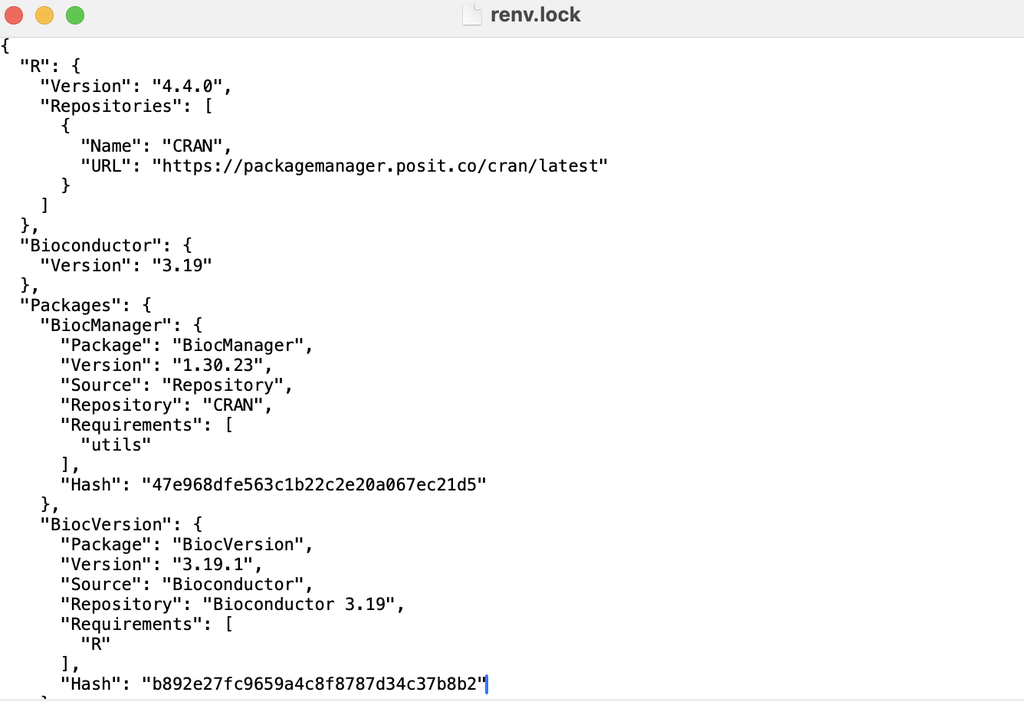

## Dockerfile with renv

R still needs to be installed to use renv, so we use Rocker again to install a specific version of R to match the renv lock file.

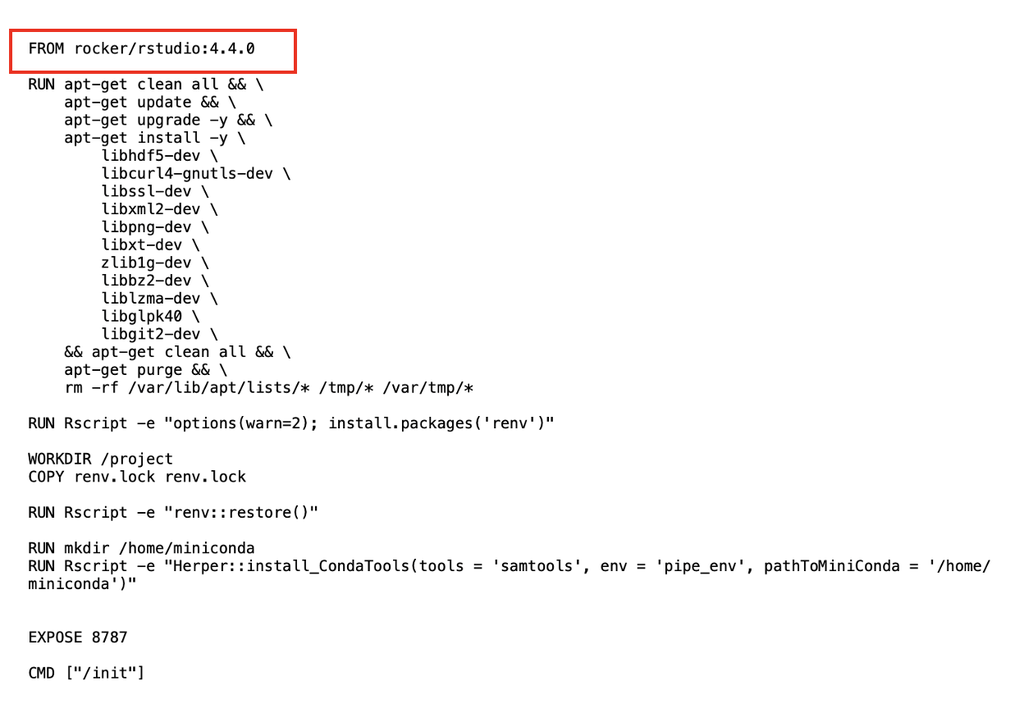

## Dockerfile with renv

The lock file is in the same directory as the Dockerfile, and when building the image the lock file is copied to the image into a directory that is created and set as the working directory with the WORKDIR command.

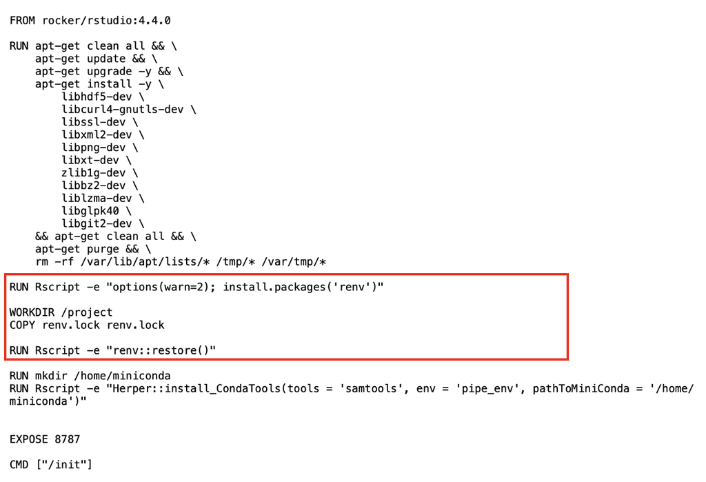

## Building image and running container

Build the image with the build context (last argument) set to the directory containing the Dockerfile and the lock file, then launch a container.

```bash
# build the image
docker image build -t rocker/rstudio:4.4.0_renv ./data/renv_docker

# launch a container
docker container run --rm \
          -v ./data:/home/rstudio \
          -p 8787:8787 \
           -e PASSWORD=password123 \
           rocker/rstudio:4.4.0_renv
```

## Contact

Any suggestions, comments, edits or questions (about content or the slides themselves) please reach out to our [GitHub](https://github.com/RockefellerUniversity/Reproducible_R/issues) and raise an issue.